# CardioVascular Risk

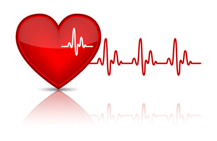

author: Tony Davidson

date: September 17 2014

### What is Cardio Vascular Disease?

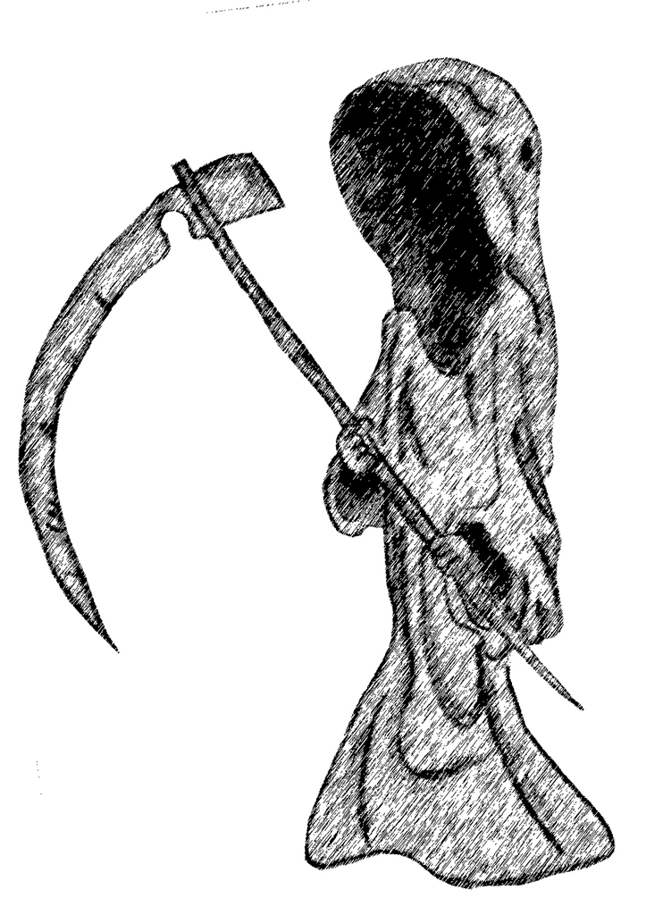

Cardio Vascular disease is a complicated way of saying there are problems with your heart and blood systems.

- It is the biggest cause of death world wide
- Since the 70's the mortality rates have been declining.
- What can you do to reduce your risk?

### The CVR Calculator (Drivers)

Key Drivers of Cardio Vascular Disease

You're Stuck with

-sex

-age

You can Control (to some extent)

-Weight

-Cholesterol Levels (good and bad)

-Whether you smoke or not

-Blood Pressure

-Diabetes (Some genetic predisposition but can be minimised)

### Your 10 year Cardio Vascular Risk

50 Year Old Woman Average Weight, Blood Pressure, Cholesterol Level. She is a smoker.

Her % Risk of having a Cardio Vascular episode is:

```
[1] 13.65
```

After she gives up smoking her % risk of a Cardio Vascular event is:

```
[1] 8.285
```

```
[1] 13.46
```

He reduces his Systolic blood pressure to 130 mmHg. His % risk is now:

```
[1] 7.415
```

### Try the CardioVascular Risk Calculator

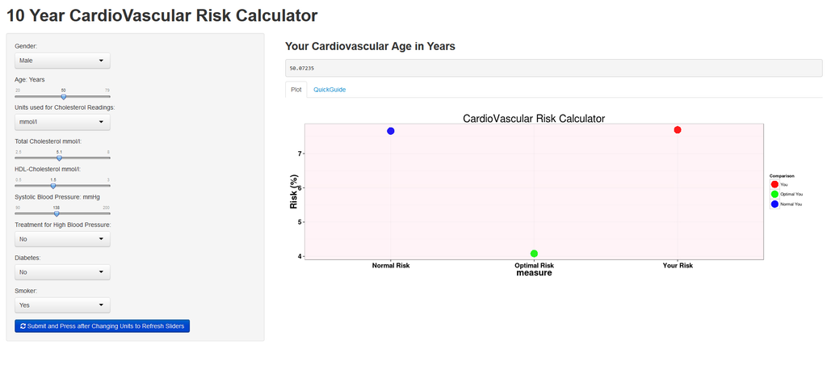

How can you and your loved ones reduce their risk?